# Multilevel Structural Equation Modeling | Exercises 1

# Where to find the mplus scripts for this lab

https://github.com/albertostefanelli/MLSEM_exercises

# Dataset

The data set used is the 7th wave of the World Values Survey. This wave is taking place in 2017-2021.

Codebook:

Between-level:

- **v2x_gender** Women political empowerment index 0 to 1 index [V-Dem, 2019]

Within-level:

- **Q31P** Men make better business executives than women do 1 to 5
- **Q33P** When jobs are scarce, men should have more right to a job than women
- **female** Assigned sex at birth (most of the countries)

# Environment preparation

First, let’s load the necessary packages to load, manipulate, visualize and analyse the data.

```r
# Uncomment this once if you need to install the packages on your system

## DATA MANIPULATION ##
# install.packages("dplyr")                 # data manipulation

## MODELING ##
# install.packages("MplusAutomation")       # Talk to Mplus from R

## TABLES ##
# install.packages("texreg")               # generates regression tables


# Load the packages

## DATA MANIPULATION ##
library("readr")
library("dplyr")

## MODELING ##
library("MplusAutomation")

## TABLES ##
library("texreg")
```

# Exercises

1. Fit a 2:1:1 model where gender job equality (Q31P) mediates the relationship between women political empowerment (v2x_gender) and gender job rights (Q33P).
2. Assess the estimated Intraclass Correlations (ICCs) for the Y variables. What is their substantive interpretation ?
3. Calculate the ICCs by hand and compare to the Mplus solution.
4. Manually calculate the number of estimated parameters for the 2:1:1 model mediation model. Compare to the Mplus solution.
5. Remove the covariance between Q33P and Q31P and see how the df change in the Mplus solution **(OPTIONAL)**
6. Manually calculate the indirect effect of women political empowerment (v2x_gender) via gender job equality (Q31P) $a \times b$ and its standard error ($\sigma_{a \times b}$) using Sobel’s formula:
   - Indirect effect = $a \times b$.
   - $\sigma_{a \times b} = \sqrt{b^2 \times \sigma_{a}^2 + a^2 \times \sigma_{b}^2}$.
7. Ask Mplus to calculate indirect and total effect. Compare the coefficient and SE of the indirect effect to your own solution.
8. Interpret the results. Does gender job equality mediates women political empowerment ? Can you interpret this result causally ?
9. Add sex (female) to the model and assess if the results change **(OPTIONAL)**

# Solutions

## 1. Fit mediaiton model in Mplus

```r
# read and prepare the data ##
wvs7 <- read_csv("https://github.com/albertostefanelli/MLSEM_exercises/raw/master/wvs7_ex_1.csv")
# transform dummy as factor as required by MplusAutomation
wvs7_f <- wvs7 %>%
          mutate_at(vars(Country, female), as.factor)
# remove feamle (need it later)
wvs7_f_m <- wvs7_f %>% select(-female)
# write the Mplus model
equality_m_model <- mplusObject(
  TITLE = "2:1:1 Mediation model with Gender Job Equality (Q31P) as mediator;",
  VARIABLE = paste(paste(strwrap(paste("USEVARIABLES = ",paste(names(wvs7_f_m), collapse=" "),
                                       ";"), 30), collapse = "\n"),
  "BETWEEN = v2x_gender;", # variable with variance ONLY at between level ß
  "CLUSTER = Country;",    # grouping variable
  sep = "\n"
  ),
  ANALYSIS = " TYPE = TWOLEVEL; ! multi-level
               PROCESSORS = 2;  ! nuber of phisical processor in your machine",
  MODEL = "
  ! within level aka LV 1
  %WITHIN%
  Q33P ON Q31P;

  ! between level aka LV 2
  %BETWEEN%
  Q33P ON v2x_gender;
  Q31P ON v2x_gender;

  ",
  rdata = wvs7_f_m
)
```

```r
## Run the model ##

equality_m_results <- mplusModeler(object = equality_m_model,         # the model syntax
                                   modelout = "equality_m_model.inp", # output file
                                   run = 1L,                          # how many models should be run (1)
                                   hashfilename = FALSE,              # add a hash of the raw data
                                   varwarnings = FALSE                # warnings about variable length
                       )
```

## 2. Assess the estimated ICCs

```r
## Mplus ICCs ##
equality_m_results$results$data_summary$ICC
```

```
  variable   ICC
1     Q33P 0.270
2     Q31P 0.193
```

The ICC provides information on the explained variance and can be interpreted as “the proportion of the variance explained by the grouping structure in the population” (Hox, Moerbeek, and Van de Schoot 2017, 6). Concretely, it tells the correlation between two observations **within** the same cluster, in the case within countries. The higher the ICC, the lower the variability is within the clusters and consequently the higher the variability is **between** the clusters. In this case, the estimated ICCs suggest that a relevant portion of the variation is between countries.

## 3. Manaully calculate ICCs

Let’s calculate the ICC by hand using the Mplus output. Remember that the ICC is the between-group-variance (random effect variance) divided by the total variance (i.e. sum of between-group-variance and within-group (residual) variance)

```r
## extract the results ##
unstd_results <- equality_m_results$results$parameters$unstandardized
# extract the residuals
residuals <- unstd_results %>%
            filter(paramHeader == "Residual.Variances" | paramHeader == "Variances")

# extract between-group-variance
residuals_between <- residuals %>%
                     filter(BetweenWithin == "Between")
residuals_between
```

```
         paramHeader param   est    se est_se pval BetweenWithin
1 Residual.Variances  Q33P 0.275 0.045  6.096    0       Between
2 Residual.Variances  Q31P 0.094 0.014  6.683    0       Between
```

```r
# extract within-group-variance
residuals_within <- residuals %>%
                    filter(BetweenWithin == "Within")
residuals_within
```

```
         paramHeader param   est    se est_se pval BetweenWithin
1          Variances  Q31P 0.690 0.032 21.779    0        Within
2 Residual.Variances  Q33P 1.078 0.053 20.462    0        Within
```

```r
## calculate ICC for Q31P ##
residuals_between_Q31P <- residuals_between %>%
                          filter(param == "Q31P")
residuals_within_Q31P <- residuals_within %>%
                         filter(param == "Q31P")

ICC_Q31P <- residuals_between_Q31P$est / (residuals_between_Q31P$est + residuals_within_Q31P$est)
ICC_Q31P
```

```
[1] 0.119898
```

```r
## calculate ICC for Q33P ##
residuals_between_Q33P <- residuals_between %>%
                          filter(param == "Q33P")
residuals_within_Q33P <- residuals_within %>%
                          filter(param == "Q33P")

ICC_Q33P <- residuals_between_Q33P$est / (residuals_between_Q33P$est + residuals_within_Q33P$est)
ICC_Q33P
```

```
[1] 0.203252
```

```r
## Compare with Mplus output ##
equality_m_results$results$data_summary$ICC
```

```
  variable   ICC
1     Q33P 0.270
2     Q31P 0.193
```

**Q:** Why do they differ?

To get the so called unconditional ICCs we need to run a null-model without (1) any substantive predictors and (2) between-level only variables. The model is estimated **only** taking into account that individuals are nested in the country where they have been interviewed.

```r
# select the cluster and the two DVs and the cluster
wvs7_icc <- wvs7_f %>%
            select(Country,
                   Q31P,
                   Q33P)

equality_baseline_model <- mplusObject(
  TITLE = "Baseline Model Q31P Q33P - ICCs calculation;",
  VARIABLE = paste(paste(strwrap(paste("USEVARIABLES = ",paste(names(wvs7_icc), collapse=" "),
                                       ";"), 30), collapse = "\n"),
  "CLUSTER = Country;",
  sep = "\n"
  ),
  ANALYSIS = "TYPE = TWOLEVEL;
             PROCESSORS = 2;",
  MODEL = "
  %WITHIN%
  Q31P;
  Q33P;

  %BETWEEN%
  Q31P;
  Q33P;
  ",
  rdata = wvs7_icc
)
```

```r
## run the model ##
equality_baseline_results <- mplusModeler(object = equality_baseline_model,
                                         modelout = "equality_baseline_model.inp",
                                         run = 1L,
                                         hashfilename = FALSE
                                    )
```

```r
## extract the results ##
unstd_results <- equality_baseline_results$results$parameters$unstandardized
# extract the residuals
residuals <- unstd_results %>%
             filter(paramHeader == "Variances")
# extract between-group-variance
residuals_between <- residuals %>%
                     filter(BetweenWithin == "Between")
residuals_between
```

```
  paramHeader param   est    se est_se pval BetweenWithin
1   Variances  Q31P 0.166 0.028  5.981    0       Between
2   Variances  Q33P 0.464 0.082  5.669    0       Between
```

```r
# extract within-group-variance
residuals_within <- residuals %>%
                    filter(BetweenWithin == "Within")
residuals_within
```

```
  paramHeader param   est    se est_se pval BetweenWithin
1   Variances  Q31P 0.690 0.032 21.788    0        Within
2   Variances  Q33P 1.251 0.060 20.792    0        Within
```

```r
## calculate ICC for Q31P ##
residuals_between_Q31P <- residuals_between %>%
                          filter(param == "Q31P")

residuals_within_Q31P <- residuals_within %>%
                          filter(param == "Q31P")

ICC_Q31P <- residuals_between_Q31P$est / (residuals_between_Q31P$est + residuals_within_Q31P$est)

ICC_Q31P
```

```
[1] 0.1939252
```

```r
## calculate ICC for Q33P ##
residuals_between_Q33P <- residuals_between %>%
                          filter(param == "Q33P")
residuals_within_Q33P <- residuals_within %>%
                          filter(param == "Q33P")

ICC_Q33P <- residuals_between_Q33P$est / (residuals_between_Q33P$est + residuals_within_Q33P$est)
ICC_Q33P
```

```
[1] 0.2705539
```

```r
## Compare with Mplus output ##
equality_baseline_results$results$data_summary$ICC
```

```
  variable   ICC
1     Q31P 0.193
2     Q33P 0.270
```

## 3. Manaully calculate the number of estimated parameters and compare to Mplus

Estimated parameters for structural models (aka without latent variables):

1. structural part = n regressions paths + n means
2. exogenous variables part = n residual variances between + n residual variances within + n covariances
3. Total number of estimated parameters = structural part + exogenous variables

```r
n_regression <- 3
n_means <- 2
n_residual_b  <- 2
n_residual_w  <- 2
n_cov  <- 1

total_n_param <- n_regression + n_means + n_residual_b + n_residual_w + n_cov

total_n_param
```

```
[1] 10
```

Compare to the Mplus solution.

```r
## extract number of estimated parameters from the model ##
equality_m_results$results$summaries$Parameters
```

```
[1] 10
```

Unsurprisingly, they are the exact same.

## 4. Remove covariance LV 2 (OPTIONAL)

By default, Mplus calculates the covariance between Q33P and Q31P at between level. This is specific to Mplus and obviously impacts the DF calculations. We can ask MPlus to avoid to calculate the covariance between Q33P and Q31P.

```r
# modify the previous model such that the covariance between Q33P and Q31P at between level is set to 0
equality_m_model_cov <- mplusObject(
  TITLE = "2:1:1 Mediation model with Gender Job Equality (Q31P) as mediator - no cov LV2 ;",
  VARIABLE = paste(paste(strwrap(paste("USEVARIABLES = ", paste(names(wvs7_f_m), collapse=" "),
                                       ";"), 30), collapse = "\n"),
  "BETWEEN = v2x_gender;",
  "CLUSTER = Country;",
  sep = "\n"
  ),
  ANALYSIS = "TYPE = TWOLEVEL;
               PROCESSORS = 2;",
  MODEL = "
  %WITHIN%
  Q33P ON Q31P

  %BETWEEN%
  Q33P ON v2x_gender
  Q31P ON v2x_gender
  Q31P WITH Q33P@0; ! covariance between Q33P and Q31P to 0
",
  rdata = wvs7_f_m
)
```

```r
## run the model ##
equality_m_model_cov_results <- mplusModeler(object = equality_m_model_cov,
                                    modelout = "equality_m_model_cov_results.inp",
                                    run = 1L,
                                    hashfilename = FALSE
                                    )
```

```r
## extract number of estimated parameters from the model ##
equality_m_model_cov_results$results$summaries$Parameters
```

[output not shown]

by setting the covariance to 0, we gained 1 degree of freedom.

## 6. Manually calculate indirect effect and its SE.

```r
## Extract parameters ##
params <- equality_m_results$results$parameters$unstandardized
## Coefficients ##
a <- params %>% filter(BetweenWithin == "Between" & paramHeader == "Q31P.ON") %>%
                select(est) %>%
                unlist() %>%
                array()

b <- params %>% filter(BetweenWithin == "Within" & paramHeader == "Q33P.ON") %>%
                select(est) %>%
                unlist() %>%
                array()


## Standard Errors ##

sigma_a <- params %>% filter(BetweenWithin == "Between" & paramHeader == "Q31P.ON") %>%
                select(se) %>%
                unlist() %>%
                array()
sigma_b <- params %>% filter(BetweenWithin == "Within" & paramHeader == "Q33P.ON") %>%
                select(se) %>%
                unlist() %>%
                array()

## Manual calculation of indirect effect a x b ##
a * b
```

```
[1] -0.943884
```

```r
## Manual calculation of the sigma a x b ##
sqrt(a^2 * sigma_b^2 + b^2 * sigma_a^2)
```

```
[1] 0.1752708
```

## 7. Ask Mplus to calculate indirect effect and SE

You can add to MODELCONSTRAINT any user specified equation. In this case, we are going to add the formula for calculating the total and the indirect effect.

```r
equality_m_model <- mplusObject(
  TITLE = "2:1:1 Mediation model with Gender Job Equality (Q31P) as mediator - total and indirect;",
  VARIABLE = paste(paste(strwrap(paste("USEVARIABLES = ", paste(names(wvs7_f_m), collapse=" "),
                                       ";"), 30), collapse = "\n"),
  "BETWEEN = v2x_gender;",
  "CLUSTER = Country;",
  sep = "\n"
  ),
  ANALYSIS = "TYPE = TWOLEVEL;
               PROCESSORS = 2;",
  MODEL = "
  %WITHIN%
  Q33P ON Q31P (b); ! add label to use in model constrain

  %BETWEEN%
  Q33P ON v2x_gender (c); ! add label to use in model constrain
  Q31P ON v2x_gender (a); ! add label to use in model constrain
  ",
  MODELCONSTRAINT = "
  NEW (ind total);
  ind = a * b; ! indirect effect
  total = c + (a * b); !ntotal effect
  ",
  rdata = wvs7_f_m
)
```

```r
## run the model ##
equality_m_results <- mplusModeler(equality_m_model,
                                    modelout = "equality_m_model.inp",
                                    run = 1L,
                                    hashfilename = FALSE
                                    )
```

```r
## extract indirect and total effect ##
params <- equality_m_results$results$parameters$unstandardized

params %>% filter(param == "IND" | param == "TOTAL")
```

```
                paramHeader param    est    se est_se pval BetweenWithin
1 New.Additional.Parameters   IND -0.945 0.160 -5.913    0       Between
2 New.Additional.Parameters TOTAL -4.005 0.704 -5.692    0       Between
```

The reason why the SE of the indirect effect $a \times b$ is different is related to method used to calculate the SE of the user defined parameter estimates (but not the path coefficients) in Mplus. While other software (e.g. Lavaan) employ the Sobel method, Mplus uses the delta method (in both MODELINDIRECT and MODELCONSTRAINT). The delta method is described in MacKinnon (2008) in the formula 4.27. It includes an added covariance term between the a and b estimates (see second line below 4.27). The main “advantage” of the delta method is that it is less conservative compared to the Sobel test. This is the same reasoning that is sometimes used to justify the use of bootstrapped SE in the calculation of mediation effects.

## 9. Add gender to the model (OPTIONAL)

```r
equality_m_model_g <- mplusObject(
  TITLE = "2:1:1 Mediation model with Gender Job Equality (Q31P) as mediator and gender (female) as LV1 predictor;",
  VARIABLE = paste(paste(strwrap(paste("USEVARIABLES = ", paste(names(wvs7_f), collapse=" "),
                                       ";"), 30), collapse = "\n"),
  "BETWEEN = v2x_gender;",
  "WITHIN = female;",
  "CLUSTER = Country;",
  sep = "\n"
  ),
  ANALYSIS = "TYPE = TWOLEVEL;
             !INTEGRATION=2
             !ESTIMATOR IS MLR;
             !ESTIMATOR = BAYES;
             PROCESSORS = 2;
             !BITERATIONS = 300000;
             !ALGORITHM=MH;
             !FBITERATIONS = 300000;
             !THIN = 2;
             !ITERATIONS = (100000)",
  MODEL = "
  %WITHIN%
  Q33P ON Q31P (b);
  Q31P ON female;
  Q33P ON female;
  Q31P;
  Q33P;

  %BETWEEN%
  Q33P ON v2x_gender (c);
  Q31P ON v2x_gender (a);

  ",
  MODELCONSTRAINT = "
  NEW (ind total);
  ind = a * b;
  total = c + (a * b);
  ",
  rdata = wvs7_f
)
```

```r
## run the model ##
equality_m_g_results<- mplusModeler(object = equality_m_model_g,
                                    modelout = "equality_m_model_g.inp",
                                    run = 1L,
                                    hashfilename = FALSE
                                    )
```

```r
## display the results ##
screenreg(equality_m_g_results)
```

```
=============================
                    TITLE
-----------------------------
W Q33P<-Q31P         0.49 ***
                    (0.02)
W Q33P<-FEMALE      -0.13 ***
                    (0.02)
W Q31P<-FEMALE      -0.25 ***
                    (0.02)
B Q33P<-V2X_GENDER  -3.04 ***
                    (0.57)
B Q31P<-V2X_GENDER  -1.86 ***
                    (0.34)
B Q31P<->Q33P        0.14 ***
                    (0.02)
B Q33P<-Intercepts   5.81 ***
                    (0.43)
B Q31P<-Intercepts   4.10 ***
                    (0.27)
W Q33P<->Q33P        1.07 ***
                    (0.05)
W Q31P<->Q31P        0.68 ***
                    (0.03)
B Q33P<->Q33P        0.28 ***
                    (0.04)
B Q31P<->Q31P        0.09 ***
                    (0.01)
B IND               -0.91 ***
                    (0.16)
B TOTAL             -3.95 ***
                    (0.70)
=============================
*** p < 0.001; ** p < 0.01; * p < 0.05
```

# BONUS - Basic Plotting from Mplus

```r
#install.packages("semPlot")
library("semPlot")
semPlot::semPaths("equality_m_model_g.out")
```

```
Reading model:  equality_m_model_g.out
```

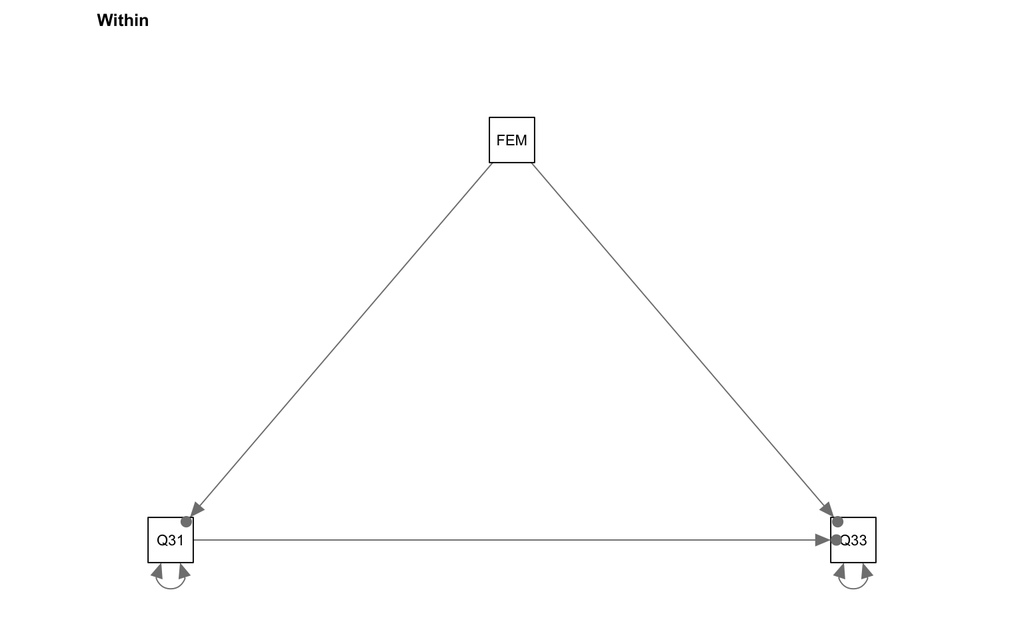

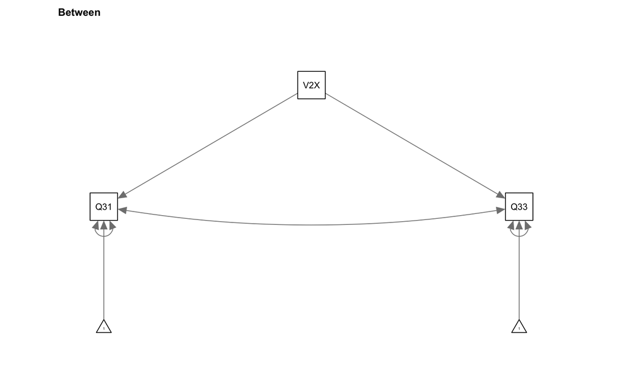

```r
#library("tidySEM")
#tidySEM::graph_sem(model = equality_m_g_results)
```

# References

Hox, Joop J, Mirjam Moerbeek, and Rens Van de Schoot. 2017. *Multilevel Analysis: Techniques and Applications*. Routledge.

MacKinnon, D. 2008. “Multivariate Applications Series.” *Introduction to Statistical Mediation Analysis*.

[^1]: [Alberto Stefanelli](https://albertostefanelli.com/)
[^2]: [Bruno Castanho Silva](https://bcastanho.github.io)